# Data Preprocessing

Data preprocessing involves cleaning and preparing the data by handling missing values, duplicates, encoding categorical variables, scaling features, and addressing outliers. This step ensures the data is ready for modeling, enhancing the accuracy of machine learning algorithms.

```python
# Import required libraries
import pandas as pd
import seaborn as sns
import matplotlib.pyplot as plt
import missingno as msno

import sys
sys.path.append(r'E:\USW\Project\car_insurance_claim_prediction\src')

import os
os.chdir(r'E:\USW\Project\car_insurance_claim_prediction\notebooks')

import importlib
import data_processing as dp

# Reload if the module was modified
importlib.reload(dp)
```

```
<module 'data_processing' from 'E:\\USW\\Project\\car_insurance_claim_prediction\\src\\data_processing.py'>
```

## **1. 🗃 Basic data preprocessing**

```python
# Define file paths
train_path = "../data/raw/train.csv"
test_path = "../data/raw/test.csv"

# Load datasets
train_df, test_df = dp.load_data(train_path, test_path)
```

**Check for Leakage**

Policy IDs should NEVER overlap

Expected Outcomes

- Success: No output (means zero overlap)
- Failure: Clear error message showing exactly which IDs leaked

```python
# Check overlap
overlap = set(train_df['policy_id']).intersection(set(test_df['policy_id']))
assert len(overlap) == 0, f"Data leakage: {len(overlap)} overlapping policy_ids found"
```

### **1.1 🗂 General Information & Structure**

#### **1.1.1 📁 Shows data types, non-null values, memory usage.**

```python
# Display train data info
print(train_df.info())
```

```
<class 'pandas.core.frame.DataFrame'>
RangeIndex: 58592 entries, 0 to 58591
Data columns (total 44 columns):
 #   Column                            Non-Null Count  Dtype
---  ------                            --------------  -----
 0   policy_id                         58592 non-null  object
 1   policy_tenure                     58592 non-null  float64
 2   age_of_car                        58592 non-null  float64
 3   age_of_policyholder               58592 non-null  float64
 4   area_cluster                      58592 non-null  object
 5   population_density                58592 non-null  int64
 6   make                              58592 non-null  int64
 7   segment                           58592 non-null  object
 8   model                             58592 non-null  object
 9   fuel_type                         58592 non-null  object
```

[output cut: 37 more lines]

```python
# Display test data info
print(test_df.info())
```

```
<class 'pandas.core.frame.DataFrame'>
RangeIndex: 39063 entries, 0 to 39062
Data columns (total 43 columns):
 #   Column                            Non-Null Count  Dtype
---  ------                            --------------  -----
 0   policy_id                         39063 non-null  object
 1   policy_tenure                     39063 non-null  float64
 2   age_of_car                        39063 non-null  float64
 3   age_of_policyholder               39063 non-null  float64
 4   area_cluster                      39063 non-null  object
 5   population_density                39063 non-null  int64
 6   make                              39063 non-null  int64
 7   segment                           39063 non-null  object
 8   model                             39063 non-null  object
 9   fuel_type                         39063 non-null  object
```

[output cut: 36 more lines]

The training dataset has 58,592 rows and 44 columns, while the test dataset contains 39,063 rows and 43 columns. Both datasets have no missing values and include a mix of numerical (e.g., age of car, policyholder, displacement) and categorical features (e.g., fuel type, segment, engine type). The training data includes a target variable is_claim, but the test data does not. The data types consist of floating point numbers, integers, and objects (for categorical variables). The training dataset uses 19.7 MB of memory, and the test dataset uses 12.8 MB.

#### **1.1.2 🧮 Lists all column names**

```python
# Display train Columns
display(train_df.columns)
```

```
Index(['policy_id', 'policy_tenure', 'age_of_car', 'age_of_policyholder',
       'area_cluster', 'population_density', 'make', 'segment', 'model',
       'fuel_type', 'max_torque', 'max_power', 'engine_type', 'airbags',
       'is_esc', 'is_adjustable_steering', 'is_tpms', 'is_parking_sensors',
       'is_parking_camera', 'rear_brakes_type', 'displacement', 'cylinder',
       'transmission_type', 'gear_box', 'steering_type', 'turning_radius',
       'length', 'width', 'height', 'gross_weight', 'is_front_fog_lights',
       'is_rear_window_wiper', 'is_rear_window_washer',
       'is_rear_window_defogger', 'is_brake_assist', 'is_power_door_locks',
       'is_central_locking', 'is_power_steering',
       'is_driver_seat_height_adjustable', 'is_day_night_rear_view_mirror',
       'is_ecw', 'is_speed_alert', 'ncap_rating', 'is_claim'],
      dtype='object')
```

```python
# Display test Columns
display(test_df.columns)
```

```
Index(['policy_id', 'policy_tenure', 'age_of_car', 'age_of_policyholder',
       'area_cluster', 'population_density', 'make', 'segment', 'model',
       'fuel_type', 'max_torque', 'max_power', 'engine_type', 'airbags',
       'is_esc', 'is_adjustable_steering', 'is_tpms', 'is_parking_sensors',
       'is_parking_camera', 'rear_brakes_type', 'displacement', 'cylinder',
       'transmission_type', 'gear_box', 'steering_type', 'turning_radius',
       'length', 'width', 'height', 'gross_weight', 'is_front_fog_lights',
       'is_rear_window_wiper', 'is_rear_window_washer',
       'is_rear_window_defogger', 'is_brake_assist', 'is_power_door_locks',
       'is_central_locking', 'is_power_steering',
       'is_driver_seat_height_adjustable', 'is_day_night_rear_view_mirror',
       'is_ecw', 'is_speed_alert', 'ncap_rating'],
      dtype='object')
```

### **1.2. 📂Preview Data - First 10 rows**

```python
display(train_df.head(10))
```

|  | policy_id | policy_tenure | age_of_car | age_of_policyholder | area_cluster | population_density | make | segment | model | fuel_type | ... | is_brake_assist | is_power_door_locks | is_central_locking | is_power_steering | is_driver_seat_height_adjustable | is_day_night_rear_view_mirror | is_ecw | is_speed_alert | ncap_rating | is_claim |
| --- | --- | --- | --- | --- | --- | --- | --- | --- | --- | --- | --- | --- | --- | --- | --- | --- | --- | --- | --- | --- | --- |
| 0 | ID00001 | 0.515874 | 0.05 | 0.644231 | C1 | 4990 | 1 | A | M1 | CNG | ... | No | No | No | Yes | No | No | No | Yes | 0 | 0 |
| 1 | ID00002 | 0.672619 | 0.02 | 0.375000 | C2 | 27003 | 1 | A | M1 | CNG | ... | No | No | No | Yes | No | No | No | Yes | 0 | 0 |
| 2 | ID00003 | 0.841110 | 0.02 | 0.384615 | C3 | 4076 | 1 | A | M1 | CNG | ... | No | No | No | Yes | No | No | No | Yes | 0 | 0 |
| 3 | ID00004 | 0.900277 | 0.11 | 0.432692 | C4 | 21622 | 1 | C1 | M2 | Petrol | ... | Yes | Yes | Yes | Yes | Yes | Yes | Yes | Yes | 2 | 0 |
| 4 | ID00005 | 0.596403 | 0.11 | 0.634615 | C5 | 34738 | 2 | A | M3 | Petrol | ... | No | Yes | Yes | Yes | No | Yes | Yes | Yes | 2 | 0 |
| 5 | ID00006 | 1.018709 | 0.07 | 0.519231 | C6 | 13051 | 3 | C2 | M4 | Diesel | ... | Yes | Yes | Yes | Yes | Yes | No | Yes | Yes | 3 | 0 |
| 6 | ID00007 | 0.097992 | 0.16 | 0.403846 | C7 | 6112 | 4 | B2 | M5 | Diesel | ... | No | Yes | Yes | Yes | No | No | Yes | Yes | 5 | 0 |
| 7 | ID00008 | 0.509085 | 0.14 | 0.423077 | C8 | 8794 | 1 | B2 | M6 | Petrol | ... | Yes | Yes | Yes | Yes | Yes | Yes | Yes | Yes | 2 | 0 |
| 8 | ID00009 | 0.282394 | 0.07 | 0.298077 | C7 | 6112 | 3 | C2 | M4 | Diesel | ... | Yes | Yes | Yes | Yes | Yes | No | Yes | Yes | 3 | 0 |
| 9 | ID00010 | 0.566255 | 0.04 | 0.442308 | C9 | 17804 | 1 | B2 | M7 | Petrol | ... | Yes | Yes | Yes | Yes | Yes | Yes | Yes | Yes | 0 | 0 |

10 rows × 44 columns

#### 1.2.1 🕸️Unique values of Categorical data

```python
# Display unique values of categorical columns excluding 'policy_id'
for col in train_df.select_dtypes(include=['object']).columns:
    if col != 'policy_id':
        print(f"Unique values in {col}: {train_df[col].unique()}")
```

```
Unique values in area_cluster: ['C1' 'C2' 'C3' 'C4' 'C5' 'C6' 'C7' 'C8' 'C9' 'C10' 'C11' 'C12' 'C13'
 'C14' 'C15' 'C16' 'C17' 'C18' 'C19' 'C20' 'C21' 'C22']
Unique values in segment: ['A' 'C1' 'C2' 'B2' 'B1' 'Utility']
Unique values in model: ['M1' 'M2' 'M3' 'M4' 'M5' 'M6' 'M7' 'M8' 'M9' 'M10' 'M11']
Unique values in fuel_type: ['CNG' 'Petrol' 'Diesel']
Unique values in max_torque: ['60Nm@3500rpm' '113Nm@4400rpm' '91Nm@4250rpm' '250Nm@2750rpm'
 '200Nm@3000rpm' '82.1Nm@3400rpm' '200Nm@1750rpm' '85Nm@3000rpm'
 '170Nm@4000rpm']
Unique values in max_power: ['40.36bhp@6000rpm' '88.50bhp@6000rpm' '67.06bhp@5500rpm'
 '113.45bhp@4000rpm' '88.77bhp@4000rpm' '55.92bhp@5300rpm'
 '97.89bhp@3600rpm' '61.68bhp@6000rpm' '118.36bhp@5500rpm']
Unique values in engine_type: ['F8D Petrol Engine' '1.2 L K12N Dualjet' '1.0 SCe' '1.5 L U2 CRDi'
 '1.5 Turbocharged Revotorq' 'K Series Dual jet' '1.2 L K Series Engine'
 'K10C' 'i-DTEC' 'G12B' '1.5 Turbocharged Revotron']
Unique values in is_esc: ['No' 'Yes']
Unique values in is_adjustable_steering: ['No' 'Yes']
Unique values in is_tpms: ['No' 'Yes']
Unique values in is_parking_sensors: ['Yes' 'No']
Unique values in is_parking_camera: ['No' 'Yes']
Unique values in rear_brakes_type: ['Drum' 'Disc']
Unique values in transmission_type: ['Manual' 'Automatic']
Unique values in steering_type: ['Power' 'Electric' 'Manual']
Unique values in is_front_fog_lights: ['No' 'Yes']
Unique values in is_rear_window_wiper: ['No' 'Yes']
Unique values in is_rear_window_washer: ['No' 'Yes']
Unique values in is_rear_window_defogger: ['No' 'Yes']
Unique values in is_brake_assist: ['No' 'Yes']
Unique values in is_power_door_locks: ['No' 'Yes']
Unique values in is_central_locking: ['No' 'Yes']
Unique values in is_power_steering: ['Yes' 'No']
Unique values in is_driver_seat_height_adjustable: ['No' 'Yes']
Unique values in is_day_night_rear_view_mirror: ['No' 'Yes']
Unique values in is_ecw: ['No' 'Yes']
Unique values in is_speed_alert: ['Yes' 'No']
```

This provided a better understanding of each column. For example, which columns were categorical or binary, and how their values were represented, such as "True/False", "Yes/No", or "1/0". It also helped identify incorrect data, NaN values, and other missing entries.

### **1.3. 🧺Checking Memory Usage - Memory usage per column**

```python
display(train_df.memory_usage(deep=True))
```

```
Index                                   132
policy_id                           3281152
policy_tenure                        468736
age_of_car                           468736
age_of_policyholder                  468736
area_cluster                        3004784
population_density                   468736
make                                 468736
segment                             2976916
model                               2989764
fuel_type                           3161570
max_torque                          3618347
max_power                           3822861
engine_type                         3722578
airbags                              468736
is_esc                              3006593
is_adjustable_steering              3023718
is_tpms                             3002210
is_parking_sensors                  3044411
is_parking_camera                   3011080
rear_brakes_type                    3105376
displacement                         468736
cylinder                             468736
transmission_type                   3283793
gear_box                             468736
steering_type                       3236820
turning_radius                       468736
length                               468736
width                                468736
height                               468736
gross_weight                         468736
is_front_fog_lights                 3022120
is_rear_window_wiper                3005150
is_rear_window_washer               3005150
is_rear_window_defogger             3008707
is_brake_assist                     3020369
is_power_door_locks                 3030627
is_central_locking                  3030627
is_power_steering                   3045575
is_driver_seat_height_adjustable    3022483
is_day_night_rear_view_mirror       3010475
is_ecw                              3030627
is_speed_alert                      3046421
ncap_rating                          468736
is_claim                             468736
dtype: int64
```

Memory usage for columns (e.g., policy_id: 3,281,152 bytes) depends on data types. Object columns (like policy_id, area_cluster, fuel_type) use more memory because they store variable-length strings, while numerical columns (int64, float64) consume less memory. To optimize, convert object columns with few unique values to category types, reducing memory usage without compromising performance.

### 1.4 🧾 Missing Values

#### 1.4.1 🧪Check Missing Values

```python
# Check missing values -Shows count of missing values per column
display(train_df.isnull().sum())
display(test_df.isnull().sum())
```

```
policy_id                           0
policy_tenure                       0
age_of_car                          0
age_of_policyholder                 0
area_cluster                        0
population_density                  0
make                                0
segment                             0
model                               0
fuel_type                           0
max_torque                          0
max_power                           0
engine_type                         0
airbags                             0
is_esc                              0
is_adjustable_steering              0
is_tpms                             0
is_parking_sensors                  0
is_parking_camera                   0
rear_brakes_type                    0
displacement                        0
cylinder                            0
transmission_type                   0
gear_box                            0
steering_type                       0
turning_radius                      0
length                              0
width                               0
height                              0
gross_weight                        0
is_front_fog_lights                 0
is_rear_window_wiper                0
is_rear_window_washer               0
is_rear_window_defogger             0
is_brake_assist                     0
is_power_door_locks                 0
is_central_locking                  0
is_power_steering                   0
is_driver_seat_height_adjustable    0
is_day_night_rear_view_mirror       0
is_ecw                              0
is_speed_alert                      0
ncap_rating                         0
is_claim                            0
dtype: int64
```

```
policy_id                           0
policy_tenure                       0
age_of_car                          0
age_of_policyholder                 0
area_cluster                        0
population_density                  0
make                                0
segment                             0
model                               0
fuel_type                           0
max_torque                          0
max_power                           0
engine_type                         0
airbags                             0
is_esc                              0
is_adjustable_steering              0
is_tpms                             0
is_parking_sensors                  0
is_parking_camera                   0
rear_brakes_type                    0
displacement                        0
cylinder                            0
transmission_type                   0
gear_box                            0
steering_type                       0
turning_radius                      0
length                              0
width                               0
height                              0
gross_weight                        0
is_front_fog_lights                 0
is_rear_window_wiper                0
is_rear_window_washer               0
is_rear_window_defogger             0
is_brake_assist                     0
is_power_door_locks                 0
is_central_locking                  0
is_power_steering                   0
is_driver_seat_height_adjustable    0
is_day_night_rear_view_mirror       0
is_ecw                              0
is_speed_alert                      0
ncap_rating                         0
dtype: int64
```

#### 1.4.2 📊 Bar Chart of missing values

**The number of missing values in each column is indicated by this bar chart**

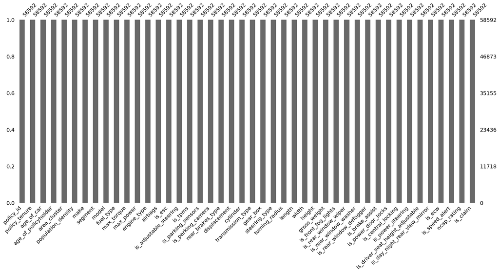

```python
# Visualize the number of missing
# values as a bar chart
msno.bar(train_df)
```

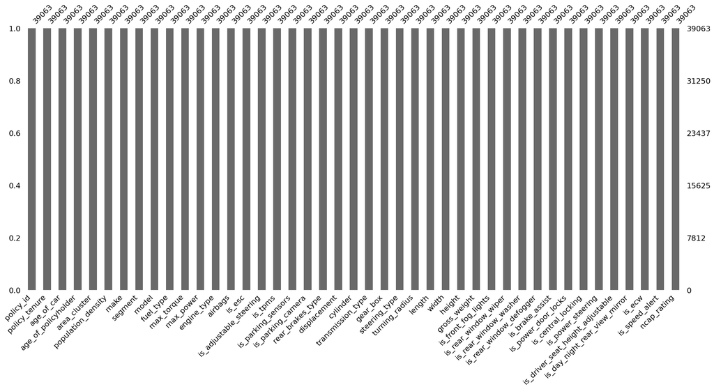

```python
msno.bar(test_df)
```

#### 1.4.3 ❌Handle Missing Values

```python
train_df = dp.handle_missing_values(train_df)
test_df = dp.handle_missing_values(test_df)
```

```
Missing values before imputation: Categorical: 0, Numerical: 0
Missing values after imputation: Categorical: 0, Numerical: 0
Missing values before imputation: Categorical: 0, Numerical: 0
Missing values after imputation: Categorical: 0, Numerical: 0
```

The assumption of no missing values in the dataset was confirmed through the info() function. However, to verify this assumption further since missing values can introduce significant bias and affect the modeling process the isnull().sum() function was used. Additionally, the missingno library was utilized to visualize any missing data.

Although no missing values were found, a missing value handling function was created using a basic approach: categorical variables are imputed with the mode, and numerical variables with the mean.

### 1.5 🔄 Handle duplicate data

#### 1.5.1 🔴In Train dataset

```python
train_df = dp.remove_duplicates(train_df)
```

```
Number of duplicate rows: 0
Dataset shape after removing duplicates: (58592, 44)
Number of duplicate rows after removing rows: 0
```

#### 1.5.2. 🟡In Test dataset

```python
test_df = dp.remove_duplicates(test_df)
```

```
Number of duplicate rows: 0
Dataset shape after removing duplicates: (39063, 43)
Number of duplicate rows after removing rows: 0
```

By using the duplicated().sum() function, it was confirmed that there are no duplicate values in the dataset. However, any potential duplicates were handled by removing the rows, just to be cautious.